# Lab 2: Spatial Analysis and Visualization

Healthcare Access and Equity in Pennsylvania

Author

Arzoo Gupta

Published

July 25, 2026

## Assignment Overview

**Learning Objectives:** - Apply spatial operations to answer policy-relevant research questions - Integrate census demographic data with spatial analysis - Create publication-quality visualizations and maps - Work with spatial data from multiple sources - Communicate findings effectively for policy audiences

## Part 1: Healthcare Access for Vulnerable Populations

### Research Question

**Which Pennsylvania counties have the highest proportion of vulnerable populations (elderly + low-income) living far from hospitals?**

#### Step 1: Data Collection

Load the required spatial data: - Pennsylvania county boundaries - Pennsylvania hospitals (from lecture data) - Pennsylvania census tracts

#### Step 2: Get Demographic Data

**Required variables:** - Total population - Median household income - Population 65 years and over (you may need to sum multiple age categories)

```
[1] 70188
```

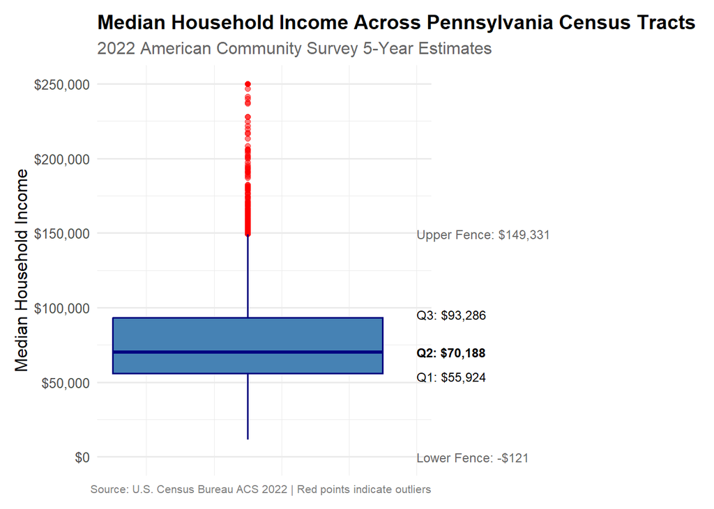

```
# A tibble: 1 × 1
  na_count
     <int>
1       63
```

I have chosen ACS 2022 Data to conduct this analysis, within this dataset 63 tracts have missing income data. The Median Income across PA is 70,188.

#### Step 3: Define Vulnerable Populations

Identifying census tracts with vulnerable populations based on TWO criteria: 1. Low median household income (choose an appropriate threshold) 2. Significant elderly population (choose an appropriate threshold)

```
# A tibble: 1 × 3
  total_tracts vulnerable_tracts pct_vulnerable
         <int>             <int>          <dbl>
1         3446               110            3.2
```

High Vulnerability Census Tracts in Pennsylvania

| Census Tract | Total Population | Pop. 65+ | % 65+ | Median Income |
| --- | --- | --- | --- | --- |
| Census Tract 9805; Allegheny County; Pennsylvania | 19 | 9 | 47.4 | $27,750 |
| Census Tract 1019; Blair County; Pennsylvania | 1,436 | 636 | 44.3 | $16,429 |
| Census Tract 8047.05; Westmoreland County; Pennsylvania | 1,082 | 471 | 43.5 | $16,029 |
| Census Tract 333; Philadelphia County; Pennsylvania | 3,730 | 1,484 | 39.8 | $49,178 |
| Census Tract 241; Philadelphia County; Pennsylvania | 1,401 | 516 | 36.8 | $16,042 |
| Census Tract 1120.02; Crawford County; Pennsylvania | 1,306 | 479 | 36.7 | $49,342 |
| Census Tract 9513; Jefferson County; Pennsylvania | 2,374 | 867 | 36.5 | $44,492 |
| Census Tract 905.02; Union County; Pennsylvania | 6,384 | 2,280 | 35.7 | $49,367 |
| Census Tract 19; Lehigh County; Pennsylvania | 3,974 | 1,412 | 35.5 | $29,429 |
| Census Tract 6025; Beaver County; Pennsylvania | 1,372 | 486 | 35.4 | $45,114 |
| Census Tract 19; Erie County; Pennsylvania | 1,705 | 602 | 35.3 | $22,219 |
| Census Tract 110.02; Blair County; Pennsylvania | 4,052 | 1,408 | 34.7 | $42,277 |
| Census Tract 5521; Allegheny County; Pennsylvania | 1,383 | 472 | 34.1 | $22,668 |
| Census Tract 282; Philadelphia County; Pennsylvania | 4,893 | 1,649 | 33.7 | $20,674 |
| Census Tract 320; Mercer County; Pennsylvania | 4,932 | 1,658 | 33.6 | $49,540 |
| Census Tract 1; Cambria County; Pennsylvania | 978 | 328 | 33.5 | $12,336 |
| Census Tract 5614; Allegheny County; Pennsylvania | 3,566 | 1,182 | 33.1 | $39,788 |
| Census Tract 114; Cambria County; Pennsylvania | 3,000 | 988 | 32.9 | $43,750 |
| Census Tract 2170.02; Luzerne County; Pennsylvania | 2,518 | 829 | 32.9 | $33,953 |
| Census Tract 1; Erie County; Pennsylvania | 1,365 | 446 | 32.7 | $14,648 |
| Census Tract 1002; Lackawanna County; Pennsylvania | 2,901 | 932 | 32.1 | $22,592 |
| Census Tract 309; Mercer County; Pennsylvania | 2,400 | 762 | 31.8 | $35,647 |
| Census Tract 9622; Indiana County; Pennsylvania | 2,261 | 713 | 31.5 | $47,895 |
| Census Tract 7827; Washington County; Pennsylvania | 1,521 | 478 | 31.4 | $37,409 |
| Census Tract 814; Northumberland County; Pennsylvania | 1,754 | 550 | 31.4 | $40,167 |
| Census Tract 4846; Allegheny County; Pennsylvania | 1,815 | 561 | 30.9 | $35,776 |
| Census Tract 314; Mercer County; Pennsylvania | 5,101 | 1,571 | 30.8 | $52,013 |
| Census Tract 9602.02; Sullivan County; Pennsylvania | 918 | 282 | 30.7 | $51,719 |
| Census Tract 9610.02; Wayne County; Pennsylvania | 2,445 | 746 | 30.5 | $54,269 |
| Census Tract 4200; Allegheny County; Pennsylvania | 1,532 | 460 | 30.0 | $43,333 |

[output cut: 80 more lines]

Note:  
High vulnerability defined as 65+ population ≥ 25% and median income < $55,000

Based on my previous analysis of the median income across all census tracts in Pennsylvania I arrived at a decision to identify all census tracts that fall below the IQ 1 or in the bottom 25% of the state will be identified as vulnerable.

The national average for 65+ population is approximately 17% and Pennsylvania’s state average sits around 19%. Setting the threshold at 25% means I am flagging tracts that are meaningfully above both the national and state baseline, representing communities where elderly residents are the dominant demographic rather than just a notable one.

A 110 tracts or 3.2% of tracts in all of PA classify as vulnerable based off of my definition.

#### Step 4: Calculate Distance to Hospitals

For each vulnerable tract, calculate the distance to the nearest hospital. *Note I converted all the CRS to albers to get the most accurate distance projected as state plane doesn’t work here because PA has two zones.

```
[1] 5070
```

```
  avg_distance_mi max_distance_mi tracts_over_15mi
1            4.83           19.32                9
```

#### Step 5: Identify Underserved Areas

Define “underserved” as vulnerable tracts that are more than 15 miles from the nearest hospital.

```
  total_vulnerable underserved pct_underserved
1              110           9             8.2
```

#### Aggregate to County Level

Use spatial joins and aggregation to calculate county-level statistics about vulnerable populations and hospital access.

```
# A tibble: 6 × 6
  COUNTY_NAM.x vulnerable_tracts underserved_tracts pct_underserved
  <chr>                    <int>              <int>           <dbl>
1 BRADFORD                     1                  1             100
2 CLEARFIELD                   4                  4             100
3 DAUPHIN                      3                  3             100
4 FOREST                       4                  4             100
5 JUNIATA                      5                  5             100
6 SULLIVAN                     4                  4             100
# ℹ 2 more variables: avg_dist_to_hospital <dbl>, total_vulnerable_pop <dbl>
```

```
# A tibble: 5 × 6
  COUNTY_NAM.x vulnerable_tracts underserved_tracts pct_underserved
  <chr>                    <int>              <int>           <dbl>
1 CRAWFORD                     6                  1            16.7
2 DAUPHIN                      3                  3           100
3 FOREST                       4                  4           100
4 CLEARFIELD                   4                  4           100
5 POTTER                       4                  3            75
# ℹ 2 more variables: avg_dist_to_hospital <dbl>, total_vulnerable_pop <dbl>
```

**Which 5 counties have the highest percentage of underserved vulnerable tracts?** Bradford, Clearfield, Forest, Juniata, and Sullivan all have 100% of their vulnerable tracts classified as underserved — every single vulnerable tract in these counties is more than 15 miles from a hospital. Dauphin is also notable at 100% with 3 tracts.

**Which counties have the most vulnerable people living far from hospitals?** From the second table Crawford, Dauphin, Forest, Clearfield, and Potter have the most vulnerable people living far from hospitals. Crawford is interesting here because it has 6 vulnerable tracts but only 1 underserved, suggesting a larger overall vulnerable population even if most tracts are within range.

**Are there any patterns in where underserved counties are located?** Yes, the pattern is very clear and geographically coherent. Almost all of these counties — Forest, Clearfield, Sullivan, Bradford, Juniata, Potter — are in **north-central and central Pennsylvania**, which is the most rural and mountainous part of the state. This region is sometimes called the Pennsylvania Wilds and is characterized by very low population density, limited road infrastructure, and a long history of hospital closures and consolidations. Dauphin being on this list is somewhat surprising given it contains Harrisburg, but this likely reflects specific rural tracts on the outskirts of the county far from the urban core.

#### Step 7: Create Summary Table

Create a professional table showing the top 10 priority counties for healthcare investment.

Top 10 Priority Counties for Healthcare Investment in Pennsylvania (2022)

[output not shown]

Note:  
Priority score weighted: 50% underserved rate, 30% average distance, 20% underserved tract ratio.

## Part 2: Comprehensive Visualization

### Map 1: County-Level Choropleth

Create a choropleth map showing healthcare access challenges at the county level.

[figure not shown]

### Map 2: Detailed Vulnerability Map

Create a map highlighting underserved vulnerable tracts.

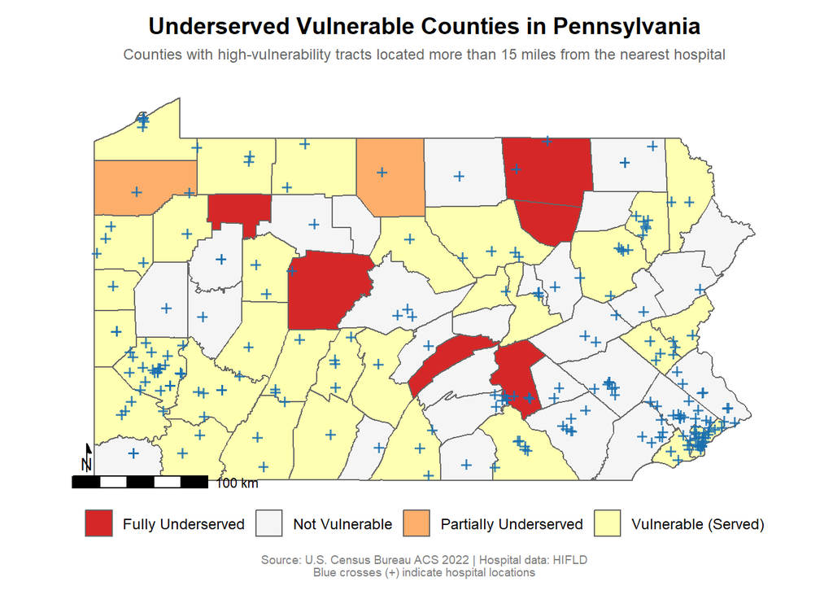

### Chart: Distribution Analysis

Create a visualization showing the distribution of distances to hospitals for vulnerable populations.

[figure not shown]

## Part 3: Bring Your Own Data Analysis

```
[1] 490
```

```
[1] 150307
```

```
[1] 5225
```

```
[1] 2272
```

```
[1] 2272
```

```
[1] 2272
```

**What dataset did you choose and why?** I chose three datasets for this analysis: Philadelphia Schools, Crime Incidents (Part 1 & Part 2), and the Bike Network, all sourced from OpenDataPhilly. I chose this combination because school safety is a pressing urban policy issue — understanding whether children traveling to school are passing through high-crime areas and whether adequate bike infrastructure exists has direct relevance for safe routes to school programs and infrastructure investment decisions.

**What is the data source and date?** All datasets were obtained from OpenDataPhilly (https://opendataphilly.org). The crime dataset contains Part 1 and Part 2 incidents reported by the Philadelphia Police Department for 2022. The schools and bike network datasets are maintained by the City of Philadelphia and reflect current infrastructure.

**How many features does it contain?** The schools dataset contains 490 schools, the crime dataset contains 150307 incidents, and the bike network contains 5,225 road segments.

**What CRS was it in? Did you need to transform it?** The schools and bike network were loaded in WGS 84 (EPSG 4326). The crime CSV used longitude/latitude coordinates also in WGS 84. All three layers were transformed to Pennsylvania State Plane South (EPSG 2272), which measures in feet and is the most appropriate projection for distance-based analysis within Philadelphia.

**Research question**

Are Philadelphia school zones safe for children walking and biking to school, and do schools located in high-crime areas have adequate bike infrastructure to support safe active transportation?”

**What this analysis will show:**

- How many crime incidents occur within 1,000ft of each school
- Which schools are in the highest crime zones
- Whether bike infrastructure exists near high-crime schools
- Whether schools lacking bike infrastructure are also in high-crime areas — the double burden of unsafe streets and inadequate infrastructure
3. **Conduct spatial analysis**

```
  total_schools avg_crime max_crime high_crime_schools pct_with_bike
1           490     234.7      2229                122          80.6
  double_burden
1            19
```

Top 10 Philadelphia Schools by Crime Incidents Within 1,000ft (2022)

| School Name | Grade Level | Crime Count | Bike Infrastructure |
| --- | --- | --- | --- |
| FREIRE CHARTER SCHOOL | MIDDLE SCHOOL | 2229 | Yes |
| FREIRE CHARTER SCHOOL | HIGH SCHOOL | 2229 | Yes |
| K012 KIDS SCHOOL | PRE-K/ELEMENTARY | 2082 | Yes |
| REVOLUTION SCHOOL | HIGH SCHOOL | 1547 | Yes |
| CONWELL, RUSSELL MIDDLE SCHOOL | MIDDLE SCHOOL | 1046 | Yes |
| JOHN B STETSON MIDDLE SCHOOL | MIDDLE SCHOOL | 974 | Yes |
| JOHN B STETSON MIDDLE SCHOOL | NA | 974 | Yes |
| WILLARD, FRANCES E. SCHOOL | ELEMENTARY SCHOOL | 802 | Yes |
| LOGAN HOPE SCHOOL | ELEMENTARY/MIDDLE | 801 | Yes |
| STUDENT TRANSITION CENTER | ELEMENTARY/MIDDLE/HIGH | 730 | Yes |

Note:  
Crime incidents include Part 1 and Part 2 offenses reported by Philadelphia Police Department

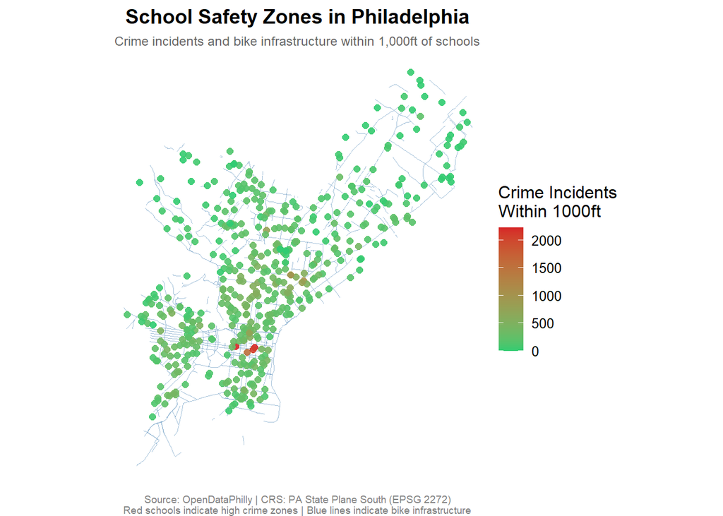

The analysis reveals that Philadelphia school zones face significant crime exposure, with an average of 234.7 crime incidents recorded within 1,000 feet of each of the city’s 490 schools. The maximum crime count of 2,229 incidents near Freire Charter School indicates that some schools are located in extremely high-activity crime corridors, particularly in dense urban neighborhoods. Of the 490 schools, 122 — roughly 25% — fall into the high crime category based on the 75th percentile threshold, suggesting that elevated crime exposure is not an isolated problem but a systemic one affecting a substantial portion of Philadelphia students. Encouragingly, 80.6% of schools have bike infrastructure within their safety zone, however 19 schools face a double burden of both high crime and no bike infrastructure, making them the highest priority for targeted safety intervention. Overall the findings suggest that while bike infrastructure coverage is relatively strong across the city, crime exposure remains a widespread challenge that warrants targeted investment in the most heavily affected school zones.

## Finally - A few comments about your incorporation of feedback!

The comment and the feedback I received in the previous assignment was to not include setup code within the assignment so it reads like a professional document, so i have attempted to remove it and have also edited the questions a bit more so it reads more coherently